# Investigating the Trade split assumption of MRIOs

# Background

Whats the trade split assumption? Problem: Trade data bases (mainly comtrade, are there others?) does report on the destinations of imported product, i.e. the industrial sector where the import goes to. So we know how much (expressed in monetary units) steel Germany imports and where (which country) this steel comes from. However, we do not know where the steel used in the German car manufacturing really comes from. Therefore, most (if not all?) MRIO tables make the assumption that the import shares of one product in one country are the same for ALL industries using that product.

# Check EXIOBASE3 for that assumption

Lets start by first loading the most recent version of EXIOBASE (3.6). It’s comes as a product by product IO table in current prices.

```r
ipath <- file.path(path2exiobase, "V3.6")
iyear <- 2011
Z <- fread(file.path(ipath, paste0("IOT_", iyear, "_pxp"), "Z.txt")) %>%
  as.matrix
```

We now select the products of the sector “Basic iron and steel and of ferro-alloys and first products thereof” which has the index 104 (out of 200 products).

```r
EB3_metadata$pxp200[grepl("steel", product200_name)]
```

| product200_code | product200_name | id |
| --- | --- | --- |
| p27.a | Basic iron and steel and of ferro-alloys and first products thereof | 104 |
| p27.a.w | Secondary steel for treatment, Re-processing of secondary steel into new steel | 105 |

```r
iprod <- seq(104, 9800, by = 200)
iprod <- matrix(rep(seq(104, 9800, by = 200), 49), ncol = 49)
diag(iprod) <- NA
Z[1123,iprod[,6]] %>% sum(na.rm = TRUE)
```

```
## [1] 257.2302
```

```r
Z[1123, iprod] %>% sum
```

```
## [1] NA
```

```r
dim(iprod)
```

```
## [1] 49 49
```

```r
isector <- 1123
```

Now we calculate the trade shares of products of that category and plot:

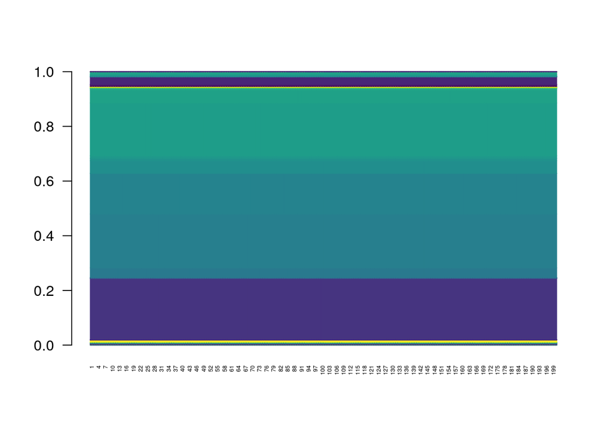

```r
Tmat <- matrix(0, nrow = 200, ncol = 9800)
for(i in 1:ncol(iprod)) {
  icountry <- (((i:(i+1))-1)*200) + 1
  zi <- Z[iprod[i], icountry[1]:(icountry[2]-1)]
  Tmat[, icountry[1]:(icountry[2]-1)] <- zi / sum(zi)
}



#dim(Tmat)
ids_GER <- EB3_metadata$colnames200[country_name == "Germany"]$id
barplot(Tmat[, ids_GER], col = viridis(48), border = viridis(48),
        names.arg = EB3_metadata$pxp200$id,
        las = 2, cex.names = 0.4)
```

```r
Tmat[, ids_GER] %>% apply(., 1, sd)
```

```
##   [1] 0 0 0 0 0 0 0 0 0 0 0 0 0 0 0 0 0 0 0 0 0 0 0 0 0 0 0 0 0 0 0 0 0 0 0
##  [36] 0 0 0 0 0 0 0 0 0 0 0 0 0 0 0 0 0 0 0 0 0 0 0 0 0 0 0 0 0 0 0 0 0 0 0
##  [71] 0 0 0 0 0 0 0 0 0 0 0 0 0 0 0 0 0 0 0 0 0 0 0 0 0 0 0 0 0 0 0 0 0 0 0
## [106] 0 0 0 0 0 0 0 0 0 0 0 0 0 0 0 0 0 0 0 0 0 0 0 0 0 0 0 0 0 0 0 0 0 0 0
## [141] 0 0 0 0 0 0 0 0 0 0 0 0 0 0 0 0 0 0 0 0 0 0 0 0 0 0 0 0 0 0 0 0 0 0 0
## [176] 0 0 0 0 0 0 0 0 0 0 0 0 0 0 0 0 0 0 0 0 0 0 0 0 0
```

And truly every sector imports steel with the exactly same import mix.